# Applied Statistics project

# By - Haritha M

## Question 1.a

| Planned to purchase Apple iPhone Xs Max | Actually placed an order for Apple iPhone Xs Max- Yes | Actually placed an order for Apple iPhone Xs Max - No | Total |
| --- | --- | --- | --- |
| Yes | 400 | 100 | 500 |
| No | 200 | 1300 | 1500 |
| Total | 600 | 1400 | 2000 |

1. Calculate the joint probability of the people who planned to purchase and actually placed an order.

From the above table, that 400 people planned to purchase and actually placed an order for Apple iPhone Xs Max is 400 out of 2000 people.

```python
# FE6 is the number of people who planned and actually placed an order for Apple iPhone Xs Max
Q1= 400
Q2  = 2000
Q3= round(Q1 / Q2,4)
print('Joint probability of the people who planned to purchase and actually placed an order. is %1.4f' % Q3)
```

```
Joint probability of the people who planned to purchase and actually placed an order. is 0.2000
```

# Conditional Probability refers to the probability of event A, given information about the occurrence of another event B

# Probability of A given B is written as P(A | B).

Probability of A given B is written as P(A | B).

$P(A\mid B) = \frac{P(A \quad and \quad B)}{P(B)}$

where P(A and B) = Joint probability of A and B

- P(A) = Marginal probability of A
- P(B) = Marginal probability of B

# Question 1.b

Find the joint probability of the people who planned to purchase and actually placed an order, given that people planned to purchase.

```python
# P1 = P(Actually placed an order | Planned to purchase)
# P2 = Planned to purchase and actually placed an order
# P3 = Planned to purchase
P1   = (400 / 2000 )/ (500 / 2000)

print('P(Actually placed an order | Planned to purchase) is %1.4f' % P1)
```

```
P(Actually placed an order | Planned to purchase) is 0.8000
```

# Binomial Distribution

It is widely used probability distribution of a discrete random variable.

Plays major role in quality control and quality assurance function.

$P(X = x\mid n,\pi)$ = $\frac{n!}{x!(n - x)!}\pi^x (1 - \pi)^{n-x} $

- where P(X = x) is the probability of getting x successes in n trials and $\pi$ is the probability of an event of interest

# Question 2

1. An electrical manufacturing company conducts quality checks at specified periods on the products it manufactures. Historically, the failure rate for the manufactured item is 5%. Suppose a random sample of 10 manufactured items is selected. Answer the following question

```python
import numpy             as np
import pandas            as pd
import scipy.stats       as stats
import matplotlib.pyplot as plt
```

# Question 2.a

Probability that none of the items are defective?

```python
X   =  0.05 # failure rate for LED light bulbs that the company manufactures is 5%
Y   =  10 # sample size
Z   =  np.arange(0,11) # An array of quantiles
```

```python
binomial = stats.binom.pmf(Z,Y,X)
```

```python
print(binomial)
```

```
[5.98736939e-01 3.15124705e-01 7.46347985e-02 1.04750594e-02
 9.64808106e-04 6.09352488e-05 2.67259863e-06 8.03789063e-08
 1.58642578e-09 1.85546875e-11 9.76562500e-14]
```

```python
print('a) None of the LED bulbs are defective? is %1.4f' %binomial[0])
```

```
a) None of the LED bulbs are defective? is 0.5987
```

# Question 2.b

2.b Probability that exactly one of the items is defective?

```python
print('b) Exactly one of the LED bulbs is defective? is %1.4f' %binomial[1])
```

```
b) Exactly one of the LED bulbs is defective? is 0.3151
```

# Question 2.c

2.C.Probability that two or fewer of the items are defective

To find this out we have to calculate cumulative probability function

```python
cumbinomial = stats.binom.cdf(Z,Y,X)
```

```python
print(cumbinomial)
```

```
[0.59873694 0.91386164 0.98849644 0.9989715  0.99993631 0.99999725
 0.99999992 1.         1.         1.         1.        ]
```

```python
print('c) Two or fewer of the LED bulbs are defective? is %1.4f' %cumbinomial[2])
```

```
c) Two or fewer of the LED bulbs are defective? is 0.9885
```

# Question 2.d

2.D.Probability that three or more of the items are defective ?

```python
#we need to subtract cumulative Probability upto 2 defective LED bulbs from 1.
P = 1- cumbinomial[2]
print('d) Three or more of the LED bulbs are defective is %1.4f' % P)
```

```
d) Three or more of the LED bulbs are defective is 0.0115
```

# Question 3

A car salesman sells on an average 3 cars per week.

Here $\lambda$ = 3

# Question 3.a

3.A.What is Probability that in a given week he will sell some cars

```python
rate =  3 # which is the mean
n    =  np.arange(0,16)
cumpoisson = stats.poisson.cdf(n,rate)
```

```python
cumpoisson
```

```
array([0.04978707, 0.19914827, 0.42319008, 0.64723189, 0.81526324,
       0.91608206, 0.96649146, 0.9880955 , 0.99619701, 0.99889751,
       0.99970766, 0.99992861, 0.99998385, 0.9999966 , 0.99999933,
       0.99999988])
```

```python
# P = probability that the agent sells some cars
P   = 1 - cumpoisson[0]
print(' a) Probability that the agent sells some cars is %1.4f' % P)
```

```
 a) Probability that the agent sells some cars is 0.9502
```

# Question 3.b

3.b What is Probability that in a given week he will sell 2 or more but less than 5 cars

```python
# Let P1 be the probability that the agent sells more than 4 cars
P1 = cumpoisson[4] # P(X >=4)
# Let P2 be the probability that the agent sells more than 1 cars
P2 = cumpoisson[1] # P(X >=1)
P = P1 - P2 # Prob. that the agent will sell between 2 and 5 cars
print(' b) Probability that the agent sells between 2 and 5 cars is %1.4f' % P)
```

```
 b) Probability that the agent sells between 2 and 5 cars is 0.6161
```

# Question 3.c

3.c Plot the poisson distribution function for cumulative probability of cars sold per-week vs number of cars sold per week.

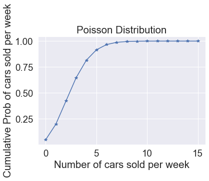

```python
poisson = stats.poisson.cdf(n,rate)
plt.plot(n,poisson, '*-')
plt.title('Poisson Distribution')
plt.xlabel('Number of cars sold per week')
plt.ylabel('Cumulative Prob of cars sold per week')
plt.show()
```

# Question 4

Accuracy in understanding orders for a speech based bot at a restaurant is important for the Company X which has designed, marketed and launched the product for a contactless delivery due to the COVID-19 pandemic. Recognition accuracy that measures the percentage of orders that are taken correctly is 86.8%. Suppose that you place an order with the bot and two friends of yours independently place orders with the same bot. Answer the following questions.

# Question 4.a

4.A.What is the probability that all three orders will be recognised correctly?

Because there are three orders and the probability of a correct order is 0.868. Using Binomial distribution equation,

```
    P(X = 3|n =3, pi given = 0.868)
      3!/ 3!(3-3)! * (0.868)^3 * (1-0.868)^3-3= 0.6540

    The probability that all the three orders are filled correctly is 0.6540, 65.4%
```

# Question 4.b

4.B.What is the probability that none of the three orders will be recognised correctly?

Because there are three orders and the probability of a correct order is 0.868. Using Binomial distribution equation,

```
  Likewise, calculate X= 0, X=2
 (X = 0) = 0.0023
 (X = 2) = 0.2984

The probability that none of the orders are filled correctly is 0.0023, 0.23%
```

# Question 4.c

4.C.What is the probability that at least two of the three orders will be recognised correctly?

Because there are three orders and the probability of a correct order is 0.868. Using Binomial distribution equation,

```
Hence, P(X>=2) = P(X=2)+P(X=3) = 0.9524

 The probability that atleat two of the three are filled correctly is 0.9524, 95.24%
```

# Question 5

Explain 1 real life industry scenario (other than the ones mentioned above) where you can use the concepts learnt in this module of Applied Statistics to get data driven business solution

# Bayes Theorem

The focus on Bayes Theorem is to calculate a probability. Bayes Theorem requires a prior assumption (information or knowledge), evidence reflected in the world. This is before seeing any evidence. The likelihood is the plausibility that our data is observed, given our prior. The posterior is the result of the Bayesian analysis, given the data and model. This can cycle through again as you update your beliefs again.

Example :

1% of women at age 40 who participate in a routine screening have breast cancer. 80% of women with breast cancer get positive mammographies. 9.6% of women without breast cancer get positive mammographies.

Let's use a population of 10,000 women.

```python
#out of10,000 women who got to a routine screening,1% will have breast cancer.
with_cancer= 0.01*10000
with_cancer
```

```
100.0
```

Here, it is important to note that the prior probability that a woman has breast cancer is 1%. This is even before getting a positive result from a mammography test. P(A) = 0.01

Bayes Theorem: P(A|B) = P(B/A) P(A) / P(B)

```python
#80% of women who have breast cancer have positive mammography test.
#80% of women who have breat cancer are correctly diagnosed by the test.
#This is the likelihood, P(B/A).
true_positive = 0.80 *100
true_positive
```

```
80.0
```

```python
#We can deduce that 20% of women who have breast cancer have false mammgraphy test.
#The test said that they have breast cancer but, in fact, they did not
false_negative = 0.20*100
false_negative
```

```
20.0
```

# Part B

```python
import numpy             as np
import pandas            as pd
import scipy.stats       as stats
import matplotlib.pyplot as plt
import seaborn           as sns
```

```python
%matplotlib inline
sns.set(style='darkgrid', palette='deep', font='sans-serif', font_scale=1.7, color_codes=True)
```

```python
basketball = pd.read_csv("C:\\Users\\HARITHA\\DS+-+Part2+-+Basketball.csv")
```

```python
basketball.head() #to check the head of the data
```

|  | Team | Tournament | Score | PlayedGames | WonGames | DrawnGames | LostGames | BasketScored | BasketGiven | TournamentChampion | Runner-up | TeamLaunch | HighestPositionHeld |
| --- | --- | --- | --- | --- | --- | --- | --- | --- | --- | --- | --- | --- | --- |
| 0 | Team 1 | 86 | 4385 | 2762 | 1647 | 552 | 563 | 5947 | 3140 | 33 | 23 | 1929 | 1 |
| 1 | Team 2 | 86 | 4262 | 2762 | 1581 | 573 | 608 | 5900 | 3114 | 25 | 25 | 1929 | 1 |
| 2 | Team 3 | 80 | 3442 | 2614 | 1241 | 598 | 775 | 4534 | 3309 | 10 | 8 | 1929 | 1 |
| 3 | Team 4 | 82 | 3386 | 2664 | 1187 | 616 | 861 | 4398 | 3469 | 6 | 6 | 1931to32 | 1 |
| 4 | Team 5 | 86 | 3368 | 2762 | 1209 | 633 | 920 | 4631 | 3700 | 8 | 7 | 1929 | 1 |

```python
# Check the tail of the dataset
basketball.tail()
```

|  | Team | Tournament | Score | PlayedGames | WonGames | DrawnGames | LostGames | BasketScored | BasketGiven | TournamentChampion | Runner-up | TeamLaunch | HighestPositionHeld |
| --- | --- | --- | --- | --- | --- | --- | --- | --- | --- | --- | --- | --- | --- |
| 56 | Team 57 | 1 | 34 | 38 | 8 | 10 | 20 | 38 | 66 | - | - | 2009-10 | 20 |
| 57 | Team 58 | 1 | 22 | 30 | 7 | 8 | 15 | 37 | 57 | - | - | 1956-57 | 16 |
| 58 | Team 59 | 1 | 19 | 30 | 7 | 5 | 18 | 51 | 85 | - | - | 1951~52 | 16 |
| 59 | Team 60 | 1 | 14 | 30 | 5 | 4 | 21 | 34 | 65 | - | - | 1955-56 | 15 |
| 60 | Team 61 | 1 | - | - | - | - | - | - | - | - | - | 2017~18 | 9 |

```python
# Get more info on it
# 1. Name of the columns
# 2. Find the data types of each columns
# 3. Look for any null/missing values
basketball.info()
```

```
<class 'pandas.core.frame.DataFrame'>
RangeIndex: 61 entries, 0 to 60
Data columns (total 13 columns):
 #   Column               Non-Null Count  Dtype
---  ------               --------------  -----
 0   Team                 61 non-null     object
 1   Tournament           61 non-null     int64
 2   Score                61 non-null     object
 3   PlayedGames          61 non-null     object
 4   WonGames             61 non-null     object
 5   DrawnGames           61 non-null     object
 6   LostGames            61 non-null     object
 7   BasketScored         61 non-null     object
 8   BasketGiven          61 non-null     object
 9   TournamentChampion   61 non-null     object
 10  Runner-up            61 non-null     object
 11  TeamLaunch           61 non-null     object
 12  HighestPositionHeld  61 non-null     int64
dtypes: int64(2), object(11)
memory usage: 6.3+ KB
```

Observations:

This dataset contains 61 observations with 13 independant attribues

All columns are of type string where as only Tournament and HighestPositionHeld are of type integer

There are No null/missing values present in the dataset

```python
# Replacae all '-' with *
basketball.replace(to_replace='-', value=0, inplace=True)

# Correction for TeamLaunch column
basketball['TeamLaunch'] = basketball['TeamLaunch'].apply(lambda year: str(year)[:4])

basketball.tail()
```

|  | Team | Tournament | Score | PlayedGames | WonGames | DrawnGames | LostGames | BasketScored | BasketGiven | TournamentChampion | Runner-up | TeamLaunch | HighestPositionHeld |
| --- | --- | --- | --- | --- | --- | --- | --- | --- | --- | --- | --- | --- | --- |
| 56 | Team 57 | 1 | 34 | 38 | 8 | 10 | 20 | 38 | 66 | 0 | 0 | 2009 | 20 |
| 57 | Team 58 | 1 | 22 | 30 | 7 | 8 | 15 | 37 | 57 | 0 | 0 | 1956 | 16 |
| 58 | Team 59 | 1 | 19 | 30 | 7 | 5 | 18 | 51 | 85 | 0 | 0 | 1951 | 16 |
| 59 | Team 60 | 1 | 14 | 30 | 5 | 4 | 21 | 34 | 65 | 0 | 0 | 1955 | 15 |
| 60 | Team 61 | 1 | 0 | 0 | 0 | 0 | 0 | 0 | 0 | 0 | 0 | 2017 | 9 |

```python
# Convert the datatype of all columns to integer except for TeamName
columns = basketball.columns
basketball[columns[1:]] = basketball[columns[1:]].astype('int64')
basketball.info()
```

```
<class 'pandas.core.frame.DataFrame'>
RangeIndex: 61 entries, 0 to 60
Data columns (total 13 columns):
 #   Column               Non-Null Count  Dtype
---  ------               --------------  -----
 0   Team                 61 non-null     object
 1   Tournament           61 non-null     int64
 2   Score                61 non-null     int64
 3   PlayedGames          61 non-null     int64
 4   WonGames             61 non-null     int64
 5   DrawnGames           61 non-null     int64
 6   LostGames            61 non-null     int64
 7   BasketScored         61 non-null     int64
 8   BasketGiven          61 non-null     int64
 9   TournamentChampion   61 non-null     int64
 10  Runner-up            61 non-null     int64
 11  TeamLaunch           61 non-null     int64
 12  HighestPositionHeld  61 non-null     int64
dtypes: int64(12), object(1)
memory usage: 6.3+ KB
```

```python
basketball.describe()
```

|  | Tournament | Score | PlayedGames | WonGames | DrawnGames | LostGames | BasketScored | BasketGiven | TournamentChampion | Runner-up | TeamLaunch | HighestPositionHeld |
| --- | --- | --- | --- | --- | --- | --- | --- | --- | --- | --- | --- | --- |
| count | 61.000000 | 61.000000 | 61.000000 | 61.000000 | 61.000000 | 61.000000 | 61.000000 | 61.000000 | 61.000000 | 61.000000 | 61.000000 | 61.000000 |
| mean | 24.000000 | 901.426230 | 796.819672 | 303.967213 | 188.934426 | 303.754098 | 1140.344262 | 1140.229508 | 1.426230 | 1.409836 | 1958.918033 | 7.081967 |
| std | 26.827225 | 1134.899121 | 876.282765 | 406.991030 | 201.799477 | 294.708594 | 1506.740211 | 1163.710766 | 5.472535 | 4.540107 | 27.484114 | 5.276663 |
| min | 1.000000 | 0.000000 | 0.000000 | 0.000000 | 0.000000 | 0.000000 | 0.000000 | 0.000000 | 0.000000 | 0.000000 | 1929.000000 | 1.000000 |
| 25% | 4.000000 | 96.000000 | 114.000000 | 34.000000 | 24.000000 | 62.000000 | 153.000000 | 221.000000 | 0.000000 | 0.000000 | 1935.000000 | 3.000000 |
| 50% | 12.000000 | 375.000000 | 423.000000 | 123.000000 | 95.000000 | 197.000000 | 430.000000 | 632.000000 | 0.000000 | 0.000000 | 1951.000000 | 6.000000 |
| 75% | 38.000000 | 1351.000000 | 1318.000000 | 426.000000 | 330.000000 | 563.000000 | 1642.000000 | 1951.000000 | 0.000000 | 0.000000 | 1978.000000 | 10.000000 |
| max | 86.000000 | 4385.000000 | 2762.000000 | 1647.000000 | 633.000000 | 1070.000000 | 5947.000000 | 3889.000000 | 33.000000 | 25.000000 | 2017.000000 | 20.000000 |

```python
basketball.shape
```

```
(61, 13)
```

To add columns of number of games cancelled,winning percentage,loosing percentage,winning Ratio, Basket Ratio etc..,

```python
#number of games cancelled
games_cancelled = basketball['PlayedGames'] - (basketball['DrawnGames'] + basketball['WonGames'] + basketball['LostGames'])
basketball.insert(loc=7, column='CancelledGames', value=games_cancelled)
basketball.head()
```

|  | Team | Tournament | Score | PlayedGames | WonGames | DrawnGames | LostGames | CancelledGames | BasketScored | BasketGiven | TournamentChampion | Runner-up | TeamLaunch | HighestPositionHeld |
| --- | --- | --- | --- | --- | --- | --- | --- | --- | --- | --- | --- | --- | --- | --- |
| 0 | Team 1 | 86 | 4385 | 2762 | 1647 | 552 | 563 | 0 | 5947 | 3140 | 33 | 23 | 1929 | 1 |
| 1 | Team 2 | 86 | 4262 | 2762 | 1581 | 573 | 608 | 0 | 5900 | 3114 | 25 | 25 | 1929 | 1 |
| 2 | Team 3 | 80 | 3442 | 2614 | 1241 | 598 | 775 | 0 | 4534 | 3309 | 10 | 8 | 1929 | 1 |
| 3 | Team 4 | 82 | 3386 | 2664 | 1187 | 616 | 861 | 0 | 4398 | 3469 | 6 | 6 | 1931 | 1 |
| 4 | Team 5 | 86 | 3368 | 2762 | 1209 | 633 | 920 | 0 | 4631 | 3700 | 8 | 7 | 1929 | 1 |

```python
#calculation of winning percentage
won_pct = basketball['WonGames'] / basketball['PlayedGames']
basketball.insert(loc=4, column='WinningPercentage', value=won_pct)
basketball.head()
```

|  | Team | Tournament | Score | PlayedGames | WinningPercentage | WonGames | DrawnGames | LostGames | CancelledGames | BasketScored | BasketGiven | TournamentChampion | Runner-up | TeamLaunch | HighestPositionHeld |
| --- | --- | --- | --- | --- | --- | --- | --- | --- | --- | --- | --- | --- | --- | --- | --- |
| 0 | Team 1 | 86 | 4385 | 2762 | 0.596307 | 1647 | 552 | 563 | 0 | 5947 | 3140 | 33 | 23 | 1929 | 1 |
| 1 | Team 2 | 86 | 4262 | 2762 | 0.572411 | 1581 | 573 | 608 | 0 | 5900 | 3114 | 25 | 25 | 1929 | 1 |
| 2 | Team 3 | 80 | 3442 | 2614 | 0.474751 | 1241 | 598 | 775 | 0 | 4534 | 3309 | 10 | 8 | 1929 | 1 |
| 3 | Team 4 | 82 | 3386 | 2664 | 0.445571 | 1187 | 616 | 861 | 0 | 4398 | 3469 | 6 | 6 | 1931 | 1 |
| 4 | Team 5 | 86 | 3368 | 2762 | 0.437726 | 1209 | 633 | 920 | 0 | 4631 | 3700 | 8 | 7 | 1929 | 1 |

```python
# calculation of lost percentage
lost_pct = basketball['LostGames'] / basketball['PlayedGames']
basketball.insert(loc=7, column='LoosingPercentage', value=lost_pct)
basketball.head()
```

|  | Team | Tournament | Score | PlayedGames | WinningPercentage | WonGames | DrawnGames | LoosingPercentage | LostGames | CancelledGames | BasketScored | BasketGiven | TournamentChampion | Runner-up | TeamLaunch | HighestPositionHeld |
| --- | --- | --- | --- | --- | --- | --- | --- | --- | --- | --- | --- | --- | --- | --- | --- | --- |
| 0 | Team 1 | 86 | 4385 | 2762 | 0.596307 | 1647 | 552 | 0.203838 | 563 | 0 | 5947 | 3140 | 33 | 23 | 1929 | 1 |
| 1 | Team 2 | 86 | 4262 | 2762 | 0.572411 | 1581 | 573 | 0.220130 | 608 | 0 | 5900 | 3114 | 25 | 25 | 1929 | 1 |
| 2 | Team 3 | 80 | 3442 | 2614 | 0.474751 | 1241 | 598 | 0.296480 | 775 | 0 | 4534 | 3309 | 10 | 8 | 1929 | 1 |
| 3 | Team 4 | 82 | 3386 | 2664 | 0.445571 | 1187 | 616 | 0.323198 | 861 | 0 | 4398 | 3469 | 6 | 6 | 1931 | 1 |
| 4 | Team 5 | 86 | 3368 | 2762 | 0.437726 | 1209 | 633 | 0.333092 | 920 | 0 | 4631 | 3700 | 8 | 7 | 1929 | 1 |

```python
#calculation of Winning ratio
won_ratio = basketball['WonGames'] / basketball['LostGames']
basketball.insert(loc=10, column='WinningRatio', value=won_ratio)
basketball.head()
```

|  | Team | Tournament | Score | PlayedGames | WinningPercentage | WonGames | DrawnGames | LoosingPercentage | LostGames | CancelledGames | WinningRatio | BasketScored | BasketGiven | TournamentChampion | Runner-up | TeamLaunch | HighestPositionHeld |
| --- | --- | --- | --- | --- | --- | --- | --- | --- | --- | --- | --- | --- | --- | --- | --- | --- | --- |
| 0 | Team 1 | 86 | 4385 | 2762 | 0.596307 | 1647 | 552 | 0.203838 | 563 | 0 | 2.925400 | 5947 | 3140 | 33 | 23 | 1929 | 1 |
| 1 | Team 2 | 86 | 4262 | 2762 | 0.572411 | 1581 | 573 | 0.220130 | 608 | 0 | 2.600329 | 5900 | 3114 | 25 | 25 | 1929 | 1 |
| 2 | Team 3 | 80 | 3442 | 2614 | 0.474751 | 1241 | 598 | 0.296480 | 775 | 0 | 1.601290 | 4534 | 3309 | 10 | 8 | 1929 | 1 |
| 3 | Team 4 | 82 | 3386 | 2664 | 0.445571 | 1187 | 616 | 0.323198 | 861 | 0 | 1.378630 | 4398 | 3469 | 6 | 6 | 1931 | 1 |
| 4 | Team 5 | 86 | 3368 | 2762 | 0.437726 | 1209 | 633 | 0.333092 | 920 | 0 | 1.314130 | 4631 | 3700 | 8 | 7 | 1929 | 1 |

```python
#calculation of Basket ratio
basket_ratio= basketball['BasketScored'] / basketball['BasketGiven']
basketball.insert(loc=11, column='BasketRatio', value=basket_ratio)
basketball.head()
```

|  | Team | Tournament | Score | PlayedGames | WinningPercentage | WonGames | DrawnGames | LoosingPercentage | LostGames | CancelledGames | WinningRatio | BasketRatio | BasketScored | BasketGiven | TournamentChampion | Runner-up | TeamLaunch | HighestPositionHeld |
| --- | --- | --- | --- | --- | --- | --- | --- | --- | --- | --- | --- | --- | --- | --- | --- | --- | --- | --- |
| 0 | Team 1 | 86 | 4385 | 2762 | 0.596307 | 1647 | 552 | 0.203838 | 563 | 0 | 2.925400 | 1.893949 | 5947 | 3140 | 33 | 23 | 1929 | 1 |
| 1 | Team 2 | 86 | 4262 | 2762 | 0.572411 | 1581 | 573 | 0.220130 | 608 | 0 | 2.600329 | 1.894669 | 5900 | 3114 | 25 | 25 | 1929 | 1 |
| 2 | Team 3 | 80 | 3442 | 2614 | 0.474751 | 1241 | 598 | 0.296480 | 775 | 0 | 1.601290 | 1.370202 | 4534 | 3309 | 10 | 8 | 1929 | 1 |
| 3 | Team 4 | 82 | 3386 | 2664 | 0.445571 | 1187 | 616 | 0.323198 | 861 | 0 | 1.378630 | 1.267801 | 4398 | 3469 | 6 | 6 | 1931 | 1 |
| 4 | Team 5 | 86 | 3368 | 2762 | 0.437726 | 1209 | 633 | 0.333092 | 920 | 0 | 1.314130 | 1.251622 | 4631 | 3700 | 8 | 7 | 1929 | 1 |

# Data Visualization :

# univariate analysis

```python
pip install seaborn==0.11.0
```

```python
#importing the libraries
import numpy             as np
import pandas            as pd
import scipy.stats       as stats
import matplotlib.pyplot as plt
import seaborn           as sns
%matplotlib inline
```

```python
basketball.info()
```

```
<class 'pandas.core.frame.DataFrame'>
RangeIndex: 61 entries, 0 to 60
Data columns (total 18 columns):
 #   Column               Non-Null Count  Dtype
---  ------               --------------  -----
 0   Team                 61 non-null     object
 1   Tournament           61 non-null     int64
 2   Score                61 non-null     int64
 3   PlayedGames          61 non-null     int64
 4   WinningPercentage    60 non-null     float64
 5   WonGames             61 non-null     int64
 6   DrawnGames           61 non-null     int64
 7   LoosingPercentage    60 non-null     float64
 8   LostGames            61 non-null     int64
 9   CancelledGames       61 non-null     int64
 10  WinningRatio         60 non-null     float64
 11  BasketRatio          60 non-null     float64
 12  BasketScored         61 non-null     int64
 13  BasketGiven          61 non-null     int64
 14  TournamentChampion   61 non-null     int64
 15  Runner-up            61 non-null     int64
 16  TeamLaunch           61 non-null     int64
 17  HighestPositionHeld  61 non-null     int64
dtypes: float64(4), int64(13), object(1)
memory usage: 8.7+ KB
```

```python
#to check the skewness
skewness=basketball.skew()
skewness
```

```
Tournament             1.217038
Score                  1.593109
PlayedGames            1.141978
WinningPercentage      1.440046
WonGames               1.805728
DrawnGames             1.004159
LoosingPercentage     -0.268561
LostGames              0.897130
CancelledGames         7.810250
WinningRatio           3.207929
BasketRatio            2.406538
BasketScored           1.777436
BasketGiven            0.975859
TournamentChampion     4.777021
Runner-up              4.360643
TeamLaunch             0.672956
HighestPositionHeld    0.817976
dtype: float64
```

```python
basketball.describe()
```

|  | Tournament | Score | PlayedGames | WinningPercentage | WonGames | DrawnGames | LoosingPercentage | LostGames | CancelledGames | WinningRatio | BasketRatio | BasketScored | BasketGiven | TournamentChampion | Runner-up | TeamLaunch | HighestPositionHeld |
| --- | --- | --- | --- | --- | --- | --- | --- | --- | --- | --- | --- | --- | --- | --- | --- | --- | --- |
| count | 61.000000 | 61.000000 | 61.000000 | 60.000000 | 61.000000 | 61.000000 | 60.000000 | 61.000000 | 61.000000 | 60.000000 | 60.000000 | 61.000000 | 61.000000 | 61.000000 | 61.000000 | 61.000000 | 61.000000 |
| mean | 24.000000 | 901.426230 | 796.819672 | 0.313648 | 303.967213 | 188.934426 | 0.449919 | 303.754098 | 0.163934 | 0.767615 | 0.804810 | 1140.344262 | 1140.229508 | 1.426230 | 1.409836 | 1958.918033 | 7.081967 |
| std | 26.827225 | 1134.899121 | 876.282765 | 0.078312 | 406.991030 | 201.799477 | 0.084009 | 294.708594 | 1.280369 | 0.450521 | 0.273057 | 1506.740211 | 1163.710766 | 5.472535 | 4.540107 | 27.484114 | 5.276663 |
| min | 1.000000 | 0.000000 | 0.000000 | 0.166667 | 0.000000 | 0.000000 | 0.203838 | 0.000000 | 0.000000 | 0.238095 | 0.384615 | 0.000000 | 0.000000 | 0.000000 | 0.000000 | 1929.000000 | 1.000000 |
| 25% | 4.000000 | 96.000000 | 114.000000 | 0.276075 | 34.000000 | 24.000000 | 0.411430 | 62.000000 | 0.000000 | 0.561616 | 0.659538 | 153.000000 | 221.000000 | 0.000000 | 0.000000 | 1935.000000 | 3.000000 |
| 50% | 12.000000 | 375.000000 | 423.000000 | 0.304917 | 123.000000 | 95.000000 | 0.457271 | 197.000000 | 0.000000 | 0.641341 | 0.736083 | 430.000000 | 632.000000 | 0.000000 | 0.000000 | 1951.000000 | 6.000000 |
| 75% | 38.000000 | 1351.000000 | 1318.000000 | 0.335402 | 426.000000 | 330.000000 | 0.485424 | 563.000000 | 0.000000 | 0.814233 | 0.834656 | 1642.000000 | 1951.000000 | 0.000000 | 0.000000 | 1978.000000 | 10.000000 |
| max | 86.000000 | 4385.000000 | 2762.000000 | 0.596307 | 1647.000000 | 633.000000 | 0.700000 | 1070.000000 | 10.000000 | 2.925400 | 1.894669 | 5947.000000 | 3889.000000 | 33.000000 | 25.000000 | 2017.000000 | 20.000000 |

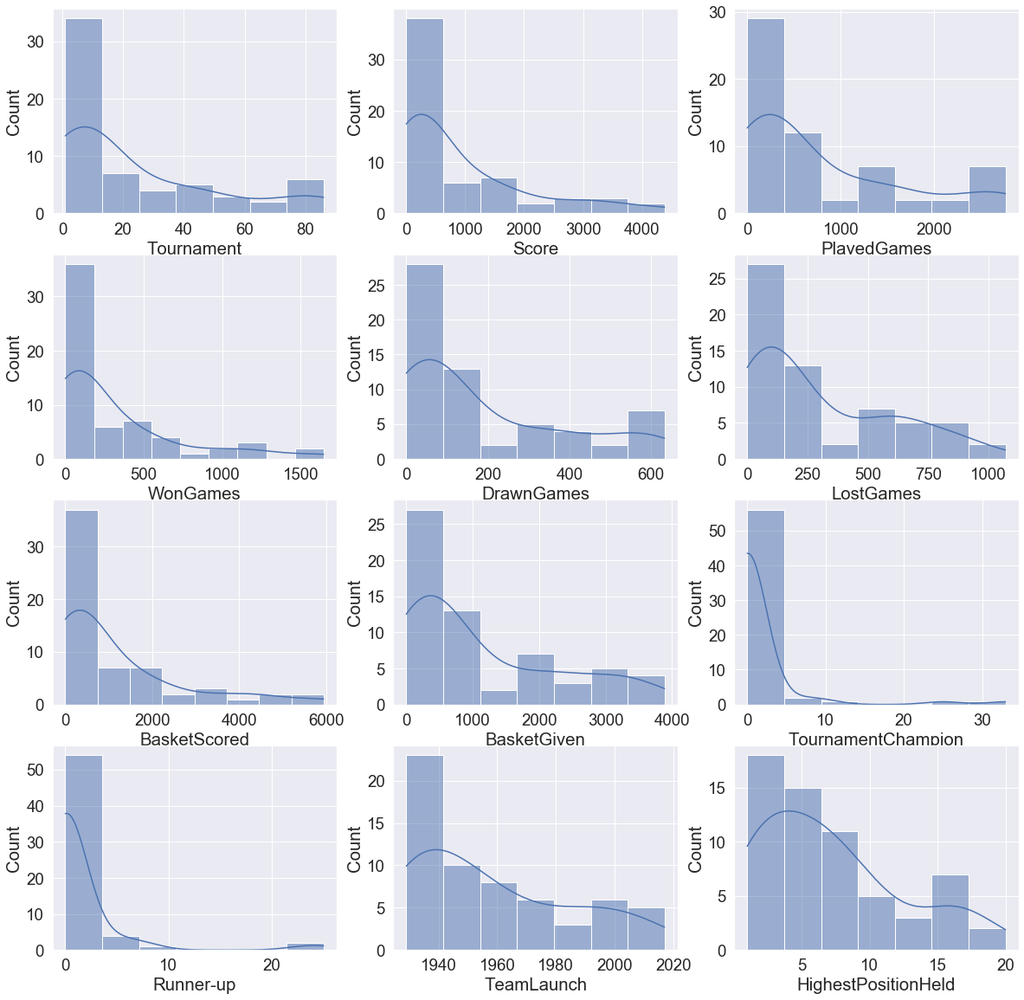

```python
attributes = ['Tournament','Score','PlayedGames','WonGames','DrawnGames','LostGames','BasketScored','BasketGiven','TournamentChampion','Runner-up','TeamLaunch','HighestPositionHeld']
plt.figure(figsize=(20,20))
index = 1
for R in basketball[attributes]:
    plt.subplot(4,3,index)
    sns.histplot(basketball[R],kde=True)
    index += 1
```

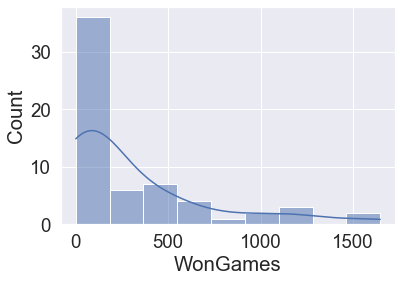

```python
#No of Games Won
sns.histplot(data=basketball,x='WonGames',kde=True);
```

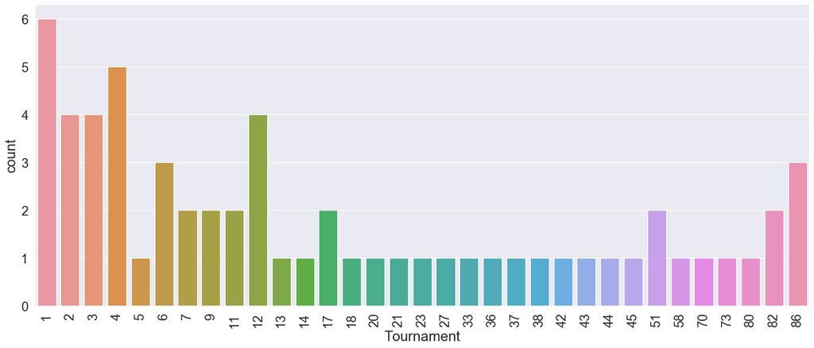

```python
# No of tournaments played by teams
plt.figure(figsize=(20,8))
sns.countplot(data=basketball,x='Tournament')
plt.xticks(rotation=90);
```

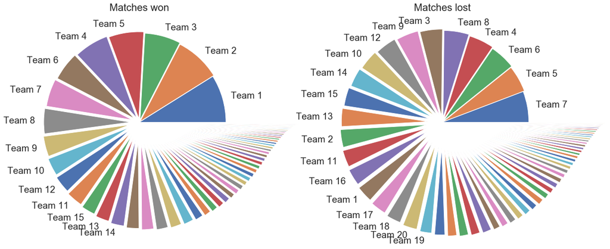

```python
# No of matches won/lost by teams
plt.figure(figsize=(20,8))
plt.subplot(1,2,1)
ab = basketball[['Team','WonGames']].sort_values(by="WonGames", ascending=False)
plot = plt.pie(ab['WonGames'], labels=list(ab['Team'][:15]) + [str()] * (len(ab)-15), explode=[0.015*x for x in range(len(ab))])
plt.title('Matches won')
plt.subplot(1,2,2)
ab = basketball[['Team','LostGames']].sort_values(by="LostGames", ascending=False)
plot = plt.pie(ab['LostGames'], labels=list(ab['Team'][:20]) + [str()] * (len(ab)-20), explode=[0.015*x for x in range(len(ab))])
plt.title('Matches lost');
```

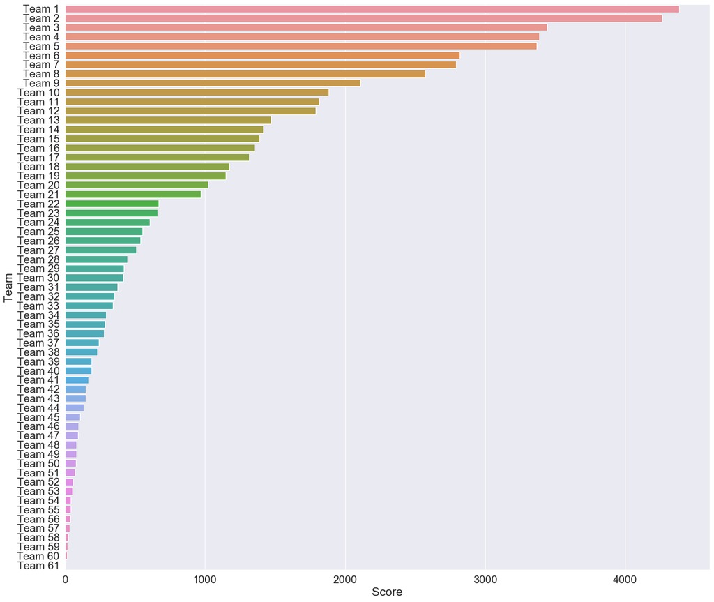

```python
#Scores of team
from matplotlib.pyplot import figure
figure(num=None, figsize=(20,18), dpi=80, facecolor='w', edgecolor='r')
sns.barplot(x="Score", y = "Team" , data =basketball)
plt.show()
```

From this we can say that the Scores of Team 1 higher when compared to other Teams

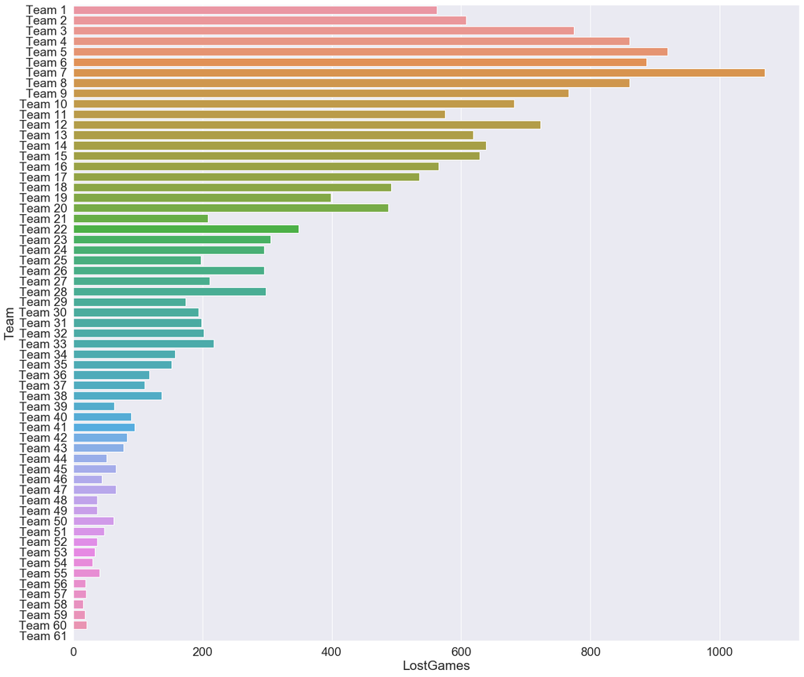

```python
#lostgames of teams
from matplotlib.pyplot import figure
figure(num=None, figsize=(20,18), dpi=80, facecolor='w', edgecolor='r')
sns.barplot(x="LostGames", y = "Team" , data =basketball)
plt.show()
```

From this we can conclude that Team 7 has lost many games when compared to other Teams

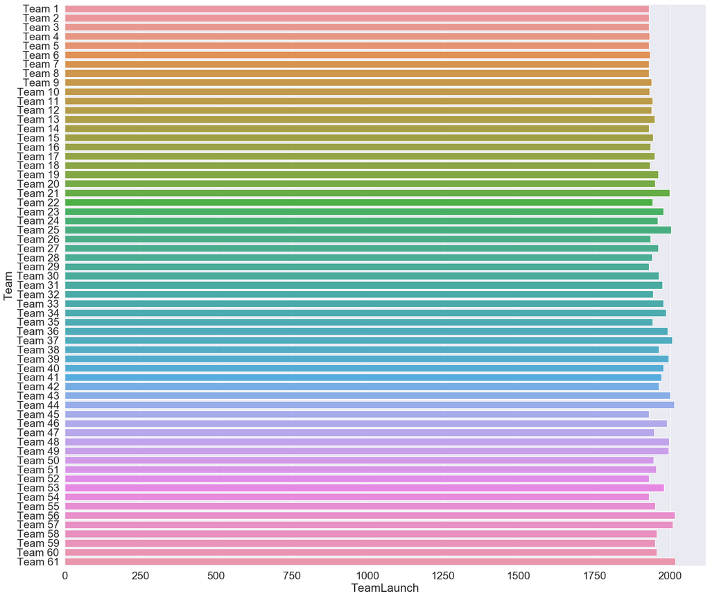

```python
#oldest teams
from matplotlib.pyplot import figure
figure(num=None, figsize=(20,18), dpi=80, facecolor='w', edgecolor='b')
sns.barplot(x="TeamLaunch", y = "Team" , data =basketball)
plt.show()
```

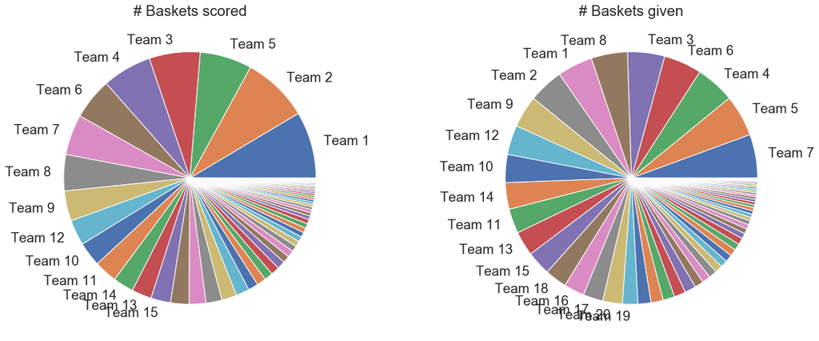

```python
# No of baskets scored/given by teams
plt.figure(figsize=(20,8))
plt.subplot(1,2,1)
bb = basketball[['Team','BasketScored']].sort_values(by="BasketScored", ascending=False)
plot = plt.pie(bb['BasketScored'], labels=list(bb['Team'][:15]) + [str()] * (len(bb)-15))
plt.title('# Baskets scored')
plt.subplot(1,2,2)
bb = basketball[['Team','BasketGiven']].sort_values(by="BasketGiven", ascending=False)
plot = plt.pie(bb['BasketGiven'], labels=list(bb['Team'][:20]) + [str()] * (len(bb)-20))
plt.title('# Baskets given')
```

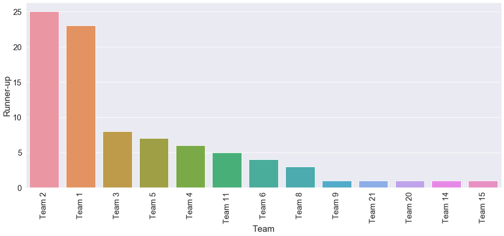

```python
# The most runner-up
plt.figure(figsize=(20,8))
ab = basketball[['Team','Runner-up']].sort_values(by="Runner-up", ascending=False).where(lambda x: x["Runner-up"] > 0)
sns.barplot(ab['Team'], ab['Runner-up'])
plt.xticks(rotation=90);
```

# Bi-variate analysis

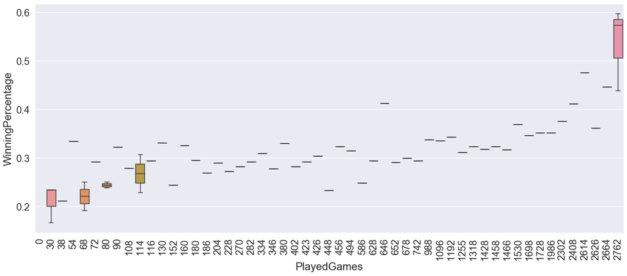

```python
#calculation of winning games by played games
plt.figure(figsize=(20,8))
sns.boxplot(data=basketball,x='PlayedGames',y='WinningPercentage')
plt.xticks(rotation=90)
plt.show();
```

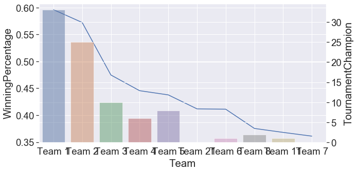

```python
#team with highest winning percentage
ax1 = sns.set_style(style=None, rc=None )
fig, ax1 = plt.subplots(figsize=(10,5))
sns.lineplot('Team', 'WinningPercentage', data = basketball.nlargest(10, 'WinningPercentage'))
ax2 = ax1.twinx()
sns.barplot(data = basketball.nlargest(10, 'WinningPercentage'), x='Team', y='TournamentChampion', alpha=0.5, ax=ax2);
```

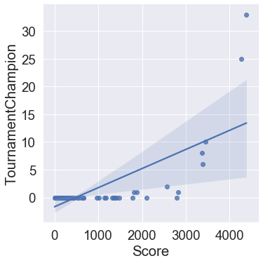

```python
sns.lmplot(data=basketball,x='Score',y='TournamentChampion')
figure(num=None, figsize=(20,18));
```

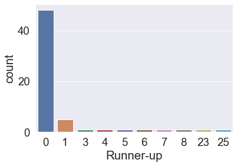

```python
sns.countplot(data=basketball,x='Runner-up');
```

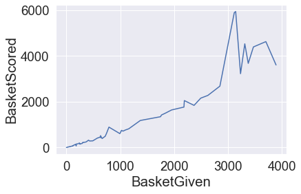

```python
#calculation of basket given by basket Scored
sns.lineplot(data=basketball,x='BasketGiven',y='BasketScored',ci=True);
```

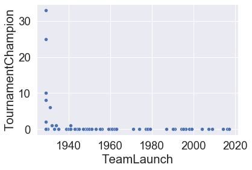

```python
#calculation of tournament champion by team launch
sns.scatterplot(data=basketball,x='TeamLaunch',y='TournamentChampion');
```

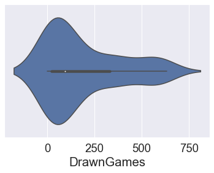

```python
sns.violinplot(data=basketball,x='DrawnGames')
plt.figure(figsize=(20,18));
```

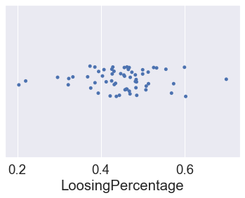

```python
#loosing percentage
sns.stripplot(data=basketball,x='LoosingPercentage');
```

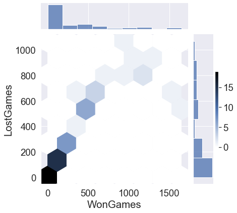

```python
sns.jointplot(data=basketball,x='WonGames',y='LostGames',kind="hex",)
plt.colorbar();
```

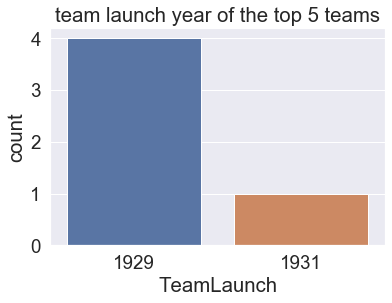

```python
#teamlaunch of top 5 teams
sns.countplot( 'TeamLaunch', data=basketball.head())
plt.title('team launch year of the top 5 teams')
plt.show();
```

```python
basketball.columns
```

```
Index(['Team', 'Tournament', 'Score', 'PlayedGames', 'WinningPercentage',
       'WonGames', 'DrawnGames', 'LoosingPercentage', 'LostGames',
       'CancelledGames', 'WinningRatio', 'BasketRatio', 'BasketScored',
       'BasketGiven', 'TournamentChampion', 'Runner-up', 'TeamLaunch',
       'HighestPositionHeld'],
      dtype='object')
```

```python
basketball[['Team', 'WinningPercentage', 'WonGames']]
```

|  | Team | WinningPercentage | WonGames |
| --- | --- | --- | --- |
| 0 | Team 1 | 0.596307 | 1647 |
| 1 | Team 2 | 0.572411 | 1581 |
| 2 | Team 3 | 0.474751 | 1241 |
| 3 | Team 4 | 0.445571 | 1187 |
| 4 | Team 5 | 0.437726 | 1209 |
| ... | ... | ... | ... |
| 56 | Team 57 | 0.210526 | 8 |
| 57 | Team 58 | 0.233333 | 7 |
| 58 | Team 59 | 0.233333 | 7 |
| 59 | Team 60 | 0.166667 | 5 |
| 60 | Team 61 | NaN | 0 |

61 rows × 3 columns

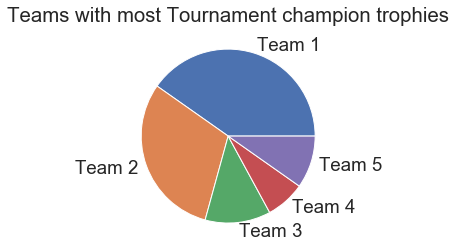

```python
plt.pie(basketball['TournamentChampion'].head(), labels= basketball['Team'].head())
plt.title('Teams with most Tournament champion trophies')
plt.show()
```

# Multivariate analysis

```python
import numpy             as np
import pandas            as pd
import scipy.stats       as stats
import matplotlib.pyplot as plt
import seaborn           as sns
```

```python
%matplotlib inline
sns.set(style='darkgrid', palette='deep', font='sans-serif', font_scale=1.7, color_codes=True)
```

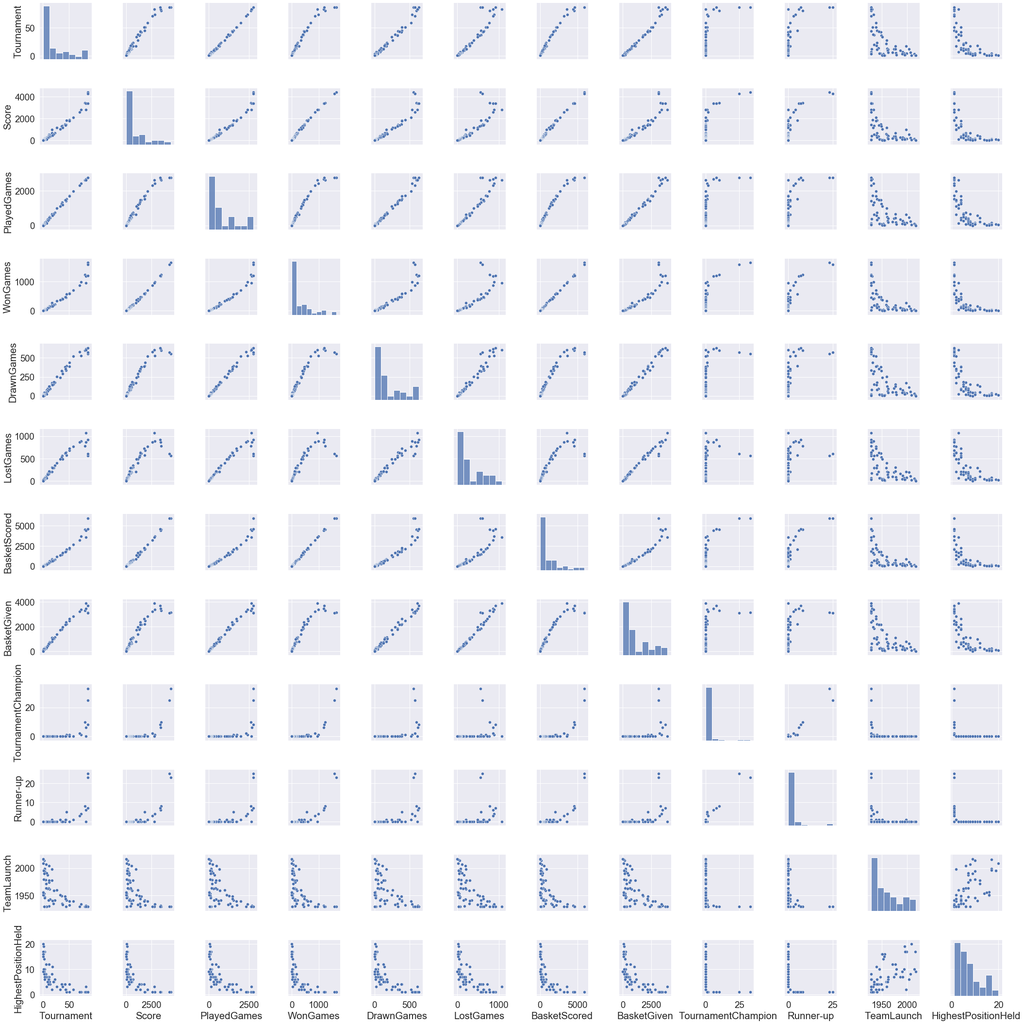

```python
# Pairwise relationship
attributes = ['Tournament','Score','PlayedGames','WonGames','DrawnGames','LostGames','BasketScored','BasketGiven','TournamentChampion','Runner-up','TeamLaunch','HighestPositionHeld']
sns.pairplot(basketball[attributes]);
```

```python
basketball.columns
```

```
Index(['Team', 'Tournament', 'Score', 'PlayedGames', 'WinningPercentage',
       'WonGames', 'DrawnGames', 'LoosingPercentage', 'LostGames',
       'CancelledGames', 'WinningRatio', 'BasketRatio', 'BasketScored',
       'BasketGiven', 'TournamentChampion', 'Runner-up', 'TeamLaunch',
       'HighestPositionHeld'],
      dtype='object')
```

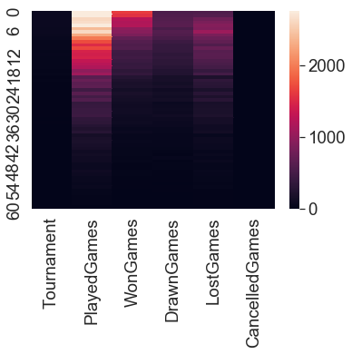

```python
sns.heatmap(basketball[['Tournament','PlayedGames','WonGames', 'DrawnGames','LostGames','CancelledGames']]);
```

# 3.Suggestion to the Association management

# Quality :

The Incomplete information about the team which makes very complicated to derive conclusion about the team. For example: There is no information about 'Team 61' score,won games, lost games,etc..., which is quiet complicated for analysis.

# Quantity :

Since the quantity of team is less we can't conclude anything with 99% accuracy . Usually we draw sample from the population which gives the accurate results of the sample. But here the ppulation itself is very less so the accurate results cannot be drawn properly.

# Variety :

It would be great if there is information about team players and their history and how many times they played in that team etc..., those kind of information would be helpful to do analysis.

# Velocity :

Well ordered or systematic record would be beneficient and supportive for data analysis.

# Veracity :

As already said our dataset is insufficient which eventually affects the results of the analysis.

# Step 1 :

Read the Csv file

```python
#importing the libraries
import numpy             as np
import pandas            as pd
import scipy.stats       as stats
import matplotlib.pyplot as plt
import seaborn           as sns
%matplotlib inline
```

```python
%matplotlib inline
sns.set(style='darkgrid', palette='deep', font='sans-serif', font_scale=1.7, color_codes=True)
```

```python
data=pd.read_csv('C:\\Users\\HARITHA\\DS+-+Part3+-+CompanyX_EU.csv')
```

```python
data.head()
```

|  | Startup | Product | Funding | Event | Result | OperatingState |
| --- | --- | --- | --- | --- | --- | --- |
| 0 | 2600Hz | 2600hz.com | NaN | Disrupt SF 2013 | Contestant | Operating |
| 1 | 3DLT | 3dlt.com | $630K | Disrupt NYC 2013 | Contestant | Closed |
| 2 | 3DPrinterOS | 3dprinteros.com | NaN | Disrupt SF 2016 | Contestant | Operating |
| 3 | 3Dprintler | 3dprintler.com | $1M | Disrupt NY 2016 | Audience choice | Operating |
| 4 | 42 Technologies | 42technologies.com | NaN | Disrupt NYC 2013 | Contestant | Operating |

# Step 2 :

# Data Exploration

2.A check the data types of each attribute

```python
data.info()
```

```
<class 'pandas.core.frame.DataFrame'>
RangeIndex: 662 entries, 0 to 661
Data columns (total 6 columns):
 #   Column          Non-Null Count  Dtype
---  ------          --------------  -----
 0   Startup         662 non-null    object
 1   Product         656 non-null    object
 2   Funding         448 non-null    object
 3   Event           662 non-null    object
 4   Result          662 non-null    object
 5   OperatingState  662 non-null    object
dtypes: object(6)
memory usage: 31.2+ KB
```

2.B Check for the null values in the attributes

```python
data.isnull()
```

|  | Startup | Product | Funding | Event | Result | OperatingState |
| --- | --- | --- | --- | --- | --- | --- |
| 0 | False | False | True | False | False | False |
| 1 | False | False | False | False | False | False |
| 2 | False | False | True | False | False | False |
| 3 | False | False | False | False | False | False |
| 4 | False | False | True | False | False | False |
| ... | ... | ... | ... | ... | ... | ... |
| 657 | False | False | False | False | False | False |
| 658 | False | False | False | False | False | False |
| 659 | False | False | False | False | False | False |
| 660 | False | False | False | False | False | False |
| 661 | False | False | False | False | False | False |

662 rows × 6 columns

# Step 3 :

# Data preprocessing & visualisation:

3.A Drop the null values

```python
# the sum of total null
data.isnull().sum()
```

```
Startup             0
Product             6
Funding           214
Event               0
Result              0
OperatingState      0
dtype: int64
```

```python
data.dropna(how='all',axis=1)
```

|  | Startup | Product | Funding | Event | Result | OperatingState |
| --- | --- | --- | --- | --- | --- | --- |
| 0 | 2600Hz | 2600hz.com | NaN | Disrupt SF 2013 | Contestant | Operating |
| 1 | 3DLT | 3dlt.com | $630K | Disrupt NYC 2013 | Contestant | Closed |
| 2 | 3DPrinterOS | 3dprinteros.com | NaN | Disrupt SF 2016 | Contestant | Operating |
| 3 | 3Dprintler | 3dprintler.com | $1M | Disrupt NY 2016 | Audience choice | Operating |
| 4 | 42 Technologies | 42technologies.com | NaN | Disrupt NYC 2013 | Contestant | Operating |
| ... | ... | ... | ... | ... | ... | ... |
| 657 | Zivity | zivity.com | $8M | TC40 2007 | Contestant | Operating |
| 658 | Zmorph | zmorph3d.com | $1M | - | Audience choice | Operating |
| 659 | Zocdoc | zocdoc.com | $223M | TC40 2007 | Contestant | Operating |
| 660 | Zula | zulaapp.com | $3.4M | Disrupt SF 2013 | Audience choice | Operating |
| 661 | Zumper | zumper.com | $31.5M | Disrupt SF 2012 | Finalist | Operating |

662 rows × 6 columns

3.B.Convert the ‘Funding’ features to a numerical value.

```python
data.info()
```

```
<class 'pandas.core.frame.DataFrame'>
RangeIndex: 662 entries, 0 to 661
Data columns (total 6 columns):
 #   Column          Non-Null Count  Dtype
---  ------          --------------  -----
 0   Startup         662 non-null    object
 1   Product         656 non-null    object
 2   Funding         448 non-null    object
 3   Event           662 non-null    object
 4   Result          662 non-null    object
 5   OperatingState  662 non-null    object
dtypes: object(6)
memory usage: 31.2+ KB
```

```python
df1= data.dropna().copy(deep=True)
df1
```

|  | Startup | Product | Funding | Event | Result | OperatingState |
| --- | --- | --- | --- | --- | --- | --- |
| 1 | 3DLT | 3dlt.com | $630K | Disrupt NYC 2013 | Contestant | Closed |
| 3 | 3Dprintler | 3dprintler.com | $1M | Disrupt NY 2016 | Audience choice | Operating |
| 5 | 5to1 | 5to1.com | $19.3M | TC50 2009 | Contestant | Acquired |
| 6 | 8 Securities | 8securities.com | $29M | Disrupt Beijing 2011 | Finalist | Operating |
| 10 | AdhereTech | adheretech.com | $1.8M | Hardware Battlefield 2014 | Contestant | Operating |
| ... | ... | ... | ... | ... | ... | ... |
| 657 | Zivity | zivity.com | $8M | TC40 2007 | Contestant | Operating |
| 658 | Zmorph | zmorph3d.com | $1M | - | Audience choice | Operating |
| 659 | Zocdoc | zocdoc.com | $223M | TC40 2007 | Contestant | Operating |
| 660 | Zula | zulaapp.com | $3.4M | Disrupt SF 2013 | Audience choice | Operating |
| 661 | Zumper | zumper.com | $31.5M | Disrupt SF 2012 | Finalist | Operating |

446 rows × 6 columns

```python
df1.loc[:,'Funds_in_million'] = df1['Funding'].apply(lambda x: float(x[1:-1])/1000 if x[-1] == 'K' else (float(x[1:-1])*1000 if x[-1] == 'B' else float(x[1:-1])))
```

```python
df1.sample(5)
```

|  | Startup | Product | Funding | Event | Result | OperatingState | Funds_in_million |
| --- | --- | --- | --- | --- | --- | --- | --- |
| 118 | Cognitive Code | cognitivecode.com | $1.3M | TC40 2007 | Contestant | Operating | 1.3 |
| 70 | Boomerang Commerce | boomerangcommerce.com | $20.5M | Disrupt NYC 2014 | Finalist | Operating | 20.5 |
| 300 | lark | lark.com | $4.1M | Disrupt SF 2010 | Contestant | Operating | 4.1 |
| 596 | Tweegee | tweegee.com | $3M | TC50 2008 | Contestant | Operating | 3.0 |
| 144 | Discovr Labs | discovrlearning.com | $100K | Disrupt SF 2015 | Contestant | Operating | 0.1 |

3.C Plot box plot for funds in million

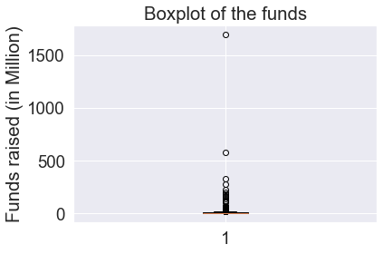

```python
plot = plt.boxplot(df1.Funds_in_million)
plt.title('Boxplot of the funds')
plt.ylabel("Funds raised (in Million)")
plt.show()
```

3.D Check the number of outliers greater than the upper fence.

```python
upper_fence = plot['caps'][1].get_data()[1][1]   # we can use the values from the box plot itself to get the upper fence
upper_fence
```

```
22.0
```

```python
print(f'Number of outliers = {len(df1[df1.Funds_in_million > upper_fence])}')

df1[df1.Funds_in_million > upper_fence]
```

```
Number of outliers = 60
```

|  | Startup | Product | Funding | Event | Result | OperatingState | Funds_in_million |
| --- | --- | --- | --- | --- | --- | --- | --- |
| 6 | 8 Securities | 8securities.com | $29M | Disrupt Beijing 2011 | Finalist | Operating | 29.0 |
| 31 | Anyclip | anyclip.com | $24M | TC50 2009 | Finalist | Operating | 24.0 |
| 40 | Artsy | artsy.net | $50.9M | Disrupt NYC 2010 | Contestant | Operating | 50.9 |
| 49 | Badgeville | badgeville.com | $40M | Disrupt SF 2010 | Finalist | Acquired | 40.0 |
| 56 | Betterment | betterment.com | $205M | Disrupt NYC 2010 | Finalist | Operating | 205.0 |
| 108 | Clickable | clickable.com | $32.5M | TC40 2007 | Finalist | Acquired | 32.5 |
| 113 | Cloudflare | cloudflare.com | $182.1M | Disrupt SF 2010 | Runner up | Operating | 182.1 |
| 128 | Credit Sesame | creditsesame.com | $35.4M | Disrupt SF 2010 | Contestant | Operating | 35.4 |
| 130 | CrowdFlower Inc. | crowdflower.com | $38M | TC50 2009 | Contestant | Operating | 38.0 |
| 132 | Cubic Telecom | cubictelecom.com | $37.1M | TC40 2007 | Contestant | Operating | 37.1 |
| 138 | DataSift | datasift.com | $72M | Disrupt SF 2010 | Finalist | Operating | 72.0 |
| 139 | DataXu | dataxu.com | $64M | TC50 2009 | Contestant | Operating | 64.0 |
| 154 | Dropbox | dropbox.com | $1.7B | TC50 2008 | Contestant | Operating | 1700.0 |
| 166 | Enigma | enigma.io | $34.6M | Disrupt NYC 2013 | Winner | Operating | 34.6 |
| 172 | EverythingMe | everything.me | $35.5M | Disrupt NYC 2011 | Contestant | Closed | 35.5 |
| 179 | Famo.us | famo.us | $30.1M | Disrupt SF 2012 | Contestant | Operating | 30.1 |
| 180 | Farmigo | farmigo.com | $26M | Disrupt SF 2011 | Finalist | Operating | 26.0 |
| 188 | Fitbit | fitbit.com | $66M | TC50 2008 | Finalist | Ipo | 66.0 |
| 191 | Flock | flock.com | $28.3M | TC40 2007 | Contestant | Acquired | 28.3 |
| 209 | Getaround | getaround.com | $103M | Disrupt NYC 2011 | Winner | Operating | 103.0 |
| 213 | Gild | gild.com | $25.9M | Disrupt SF 2010 | Contestant | Acquired | 25.9 |
| 215 | Glide | glide.me | $36.5M | Disrupt NYC 2013 | Audience choice | Operating | 36.5 |
| 225 | Grockit | grockit.com | $44.7M | TC50 2008 | Finalist | Acquired | 44.7 |
| 231 | HackerRank | hackerrank.com | $24.2M | Disrupt SF 2012 | Contestant | Operating | 24.2 |
| 271 | Ionic Security | ionicsecurity.com | $122.4M | Disrupt SF 2012 | Contestant | Operating | 122.4 |
| 276 | IZEA | izea.com | $34.9M | Disrupt NYC 2010 | Contestant | Ipo | 34.9 |
| 279 | Jiff | jiff.com | $67.8M | Disrupt SF 2011 | Contestant | Acquired | 67.8 |
| 282 | Kaltura | kaltura.com | $166.1M | TC40 2007 | Audience choice | Operating | 166.1 |
| 302 | Layer | layer.com | $42.1M | Disrupt SF 2013 | Winner | Operating | 42.1 |
| 305 | LearnVest | learnvest.com | $69M | TC50 2009 | Contestant | Acquired | 69.0 |
| 313 | LiveIntent | liveintent.com | $65.1M | Disrupt NYC 2010 | Audience choice | Operating | 65.1 |
| 325 | Lystable | lystable.com | $25.1M | Disrupt London 2015 | Finalist | Operating | 25.1 |
| 346 | Mint | mint.com | $31.8M | TC40 2007 | Winner | Acquired | 31.8 |
| 389 | OrderWithMe | orderwithme.com | $37M | Disrupt Beijing 2011 | Winner | Operating | 37.0 |
| 393 | Osmo | playosmo.com | $38.5M | Disrupt SF 2013 | Contestant | Operating | 38.5 |
| 394 | Ossia | ossia.com | $25.5M | Disrupt SF 2013 | Runner up | Operating | 25.5 |
| 398 | Owlet Baby Care | owletcare.com | $24M | Hardware Battlefield 2014 | Runner up | Operating | 24.0 |
| 427 | Postmates | postmates.com | $278M | Disrupt SF 2011 | Contestant | Operating | 278.0 |
| 432 | Prism Skylabs | prism.com | $24M | Disrupt SF 2011 | Runner up | Operating | 24.0 |
| 435 | PubMatic | pubmatic.com | $63M | TC40 2007 | Contestant | Operating | 63.0 |
| 460 | Roadie | roadie.com | $25M | Disrupt NYC 2014 | Audience choice | Operating | 25.0 |
| 471 | SeatGeek | seatgeek.com | $160M | TC50 2009 | Contestant | Operating | 160.0 |
| 546 | StyleSeat | styleseat.com | $40M | Disrupt NYC 2011 | Contestant | Operating | 40.0 |
| 555 | Symphony Commerce | symphonycommerce.com | $47.4M | Disrupt NYC 2011 | Contestant | Operating | 47.4 |
| 560 | Talkdesk | talkdesk.com | $24.5M | Disrupt NYC 2012 | Contestant | Operating | 24.5 |
| 581 | TouchPal | touchpal.com | $25M | Disrupt Beijing 2011 | Finalist | Operating | 25.0 |
| 593 | TrueCar | truecar.com | $332.4M | TC50 2008 | Contestant | Ipo | 332.4 |
| 598 | UberConference | uberconference.com | $35M | Disrupt NYC 2012 | Winner | Operating | 35.0 |
| 606 | Upwork | upwork.com | $168.8M | TC50 2009 | Audience choice | Operating | 168.8 |
| 615 | VideoSurf | videosurf.com | $28M | TC50 2008 | Contestant | Acquired | 28.0 |
| 625 | Voxy | voxy.com | $30.8M | Disrupt SF 2010 | Contestant | Operating | 30.8 |
| 643 | Xobni | yahoo.com | $41.8M | TC40 2007 | Contestant | Acquired | 41.8 |
| 644 | Yammer | yammer.com | $142M | TC50 2008 | Winner | Acquired | 142.0 |
| 647 | Yext | yext.com | $117.8M | TC50 2009 | Contestant | Ipo | 117.8 |
| 649 | YouNow | younow.com | $26M | Disrupt SF 2011 | Contestant | Operating | 26.0 |
| 650 | YourMechanic | yourmechanic.com | $28M | Disrupt SF 2012 | Winner | Operating | 28.0 |
| 654 | ZEFR | zefr.com | $62.1M | Disrupt NYC 2010 | Contestant | Operating | 62.1 |
| 656 | Zenefits | zenefits.com | $583.6M | Disrupt NYC 2013 | Finalist | Operating | 583.6 |
| 659 | Zocdoc | zocdoc.com | $223M | TC40 2007 | Contestant | Operating | 223.0 |
| 661 | Zumper | zumper.com | $31.5M | Disrupt SF 2012 | Finalist | Operating | 31.5 |

```python
df1.drop(df1[df1.Funds_in_million > upper_fence].index, inplace = True)#greater than upper fence
```

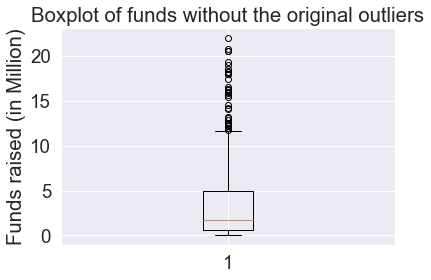

```python
plot = plt.boxplot(df1.Funds_in_million)
plt.title('Boxplot of funds without the original outliers')
plt.ylabel("Funds raised (in Million)")
plt.show()
```

3.E Check frequency of the OperatingState features classes.

```python
df1.OperatingState.value_counts()
```

```
Operating    275
Closed        56
Acquired      55
Name: OperatingState, dtype: int64
```

# Step 4 :

# Statistical analysis :

4.A.Is there any significant difference between Funds raised by companies that are still operating vs companies that closed down?

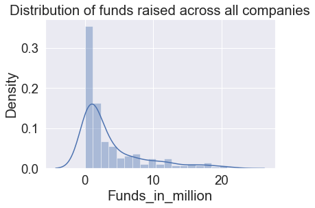

```python
import seaborn as sns
sns.distplot(df1.Funds_in_million)
plt.title('Distribution of funds raised across all companies')
plt.show()
```

```python
df1.Funds_in_million.describe()
```

```
count    386.00000
mean       3.72514
std        4.73236
min        0.00500
25%        0.60000
50%        1.70000
75%        5.00000
max       22.00000
Name: Funds_in_million, dtype: float64
```

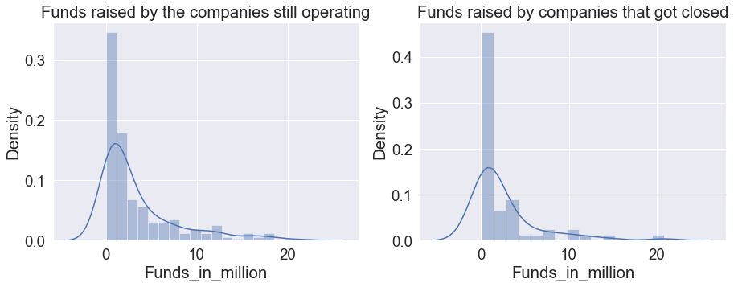

```python
fig, ax = plt.subplots(1, 2)
fig.set_figheight(5)
fig.set_figwidth(15)
sns.distplot(df1.loc[df1.OperatingState == 'Operating', 'Funds_in_million'], ax = ax[0])
sns.distplot(df1.loc[df1.OperatingState =='Closed', 'Funds_in_million'], ax = ax[1])
ax[0].set_title('Funds raised by the companies still operating')
ax[1].set_title('Funds raised by companies that got closed')
plt.show();
```

4.B Write the null hypothesis and alternative hypothesis.

**Null hypothesis (Ho)** : There is no difference between the two means

**Alternate hypothesis (Ha)** : There is significant difference between the two means

```python
from statsmodels.stats.weightstats import ztest

sample1 = df1.loc[df1.OperatingState == 'Operating', 'Funds_in_million']
sample2 = df1.loc[df1.OperatingState =='Closed', 'Funds_in_million']

alpha = 0.05   # Let's consider a significance level of 5%

test_statistic, p_value = ztest(sample1, sample2)

if p_value <= alpha:
    print(f'Since the p-value, {round(p_value, 3)} < {alpha} (alpha) the difference is significant and we reject the Null hypothesis')
else:
    print(f'''\t Since the p-value, {round(p_value,3)} > {alpha} (alpha) the difference is not significant and,
    \t we fail to reject the Null hypothesis''')
```

```
	 Since the p-value, 0.192 > 0.05 (alpha) the difference is not significant and,
    	 we fail to reject the Null hypothesis
```

```python
from scipy.stats import ttest_ind

test_statistic, p_value = ttest_ind(sample1, sample2)

if p_value <= alpha:
    print(f'Since the p-value, {round(p_value, 3)} < {alpha} (alpha) the difference is significant and we reject the Null hypothesis')
else:
    print(f'''\t Since the p-value, {round(p_value,3)} > {alpha} (alpha) the difference is not significant and,
    \t we fail to reject the Null hypothesis''')
```

```
	 Since the p-value, 0.193 > 0.05 (alpha) the difference is not significant and,
    	 we fail to reject the Null hypothesis
```

4.C Test for significance and conclusion.

- Since the p-value, 0.193 > 0.05 (alpha) the difference is not significant and,

  ```
     we fail to reject the Null hypothesis
  ```

4.D Make a copy of the original data frame. [1 Mark]

```python
df1 = data.copy(deep = True)
df1.head()
```

|  | Startup | Product | Funding | Event | Result | OperatingState |
| --- | --- | --- | --- | --- | --- | --- |
| 0 | 2600Hz | 2600hz.com | NaN | Disrupt SF 2013 | Contestant | Operating |
| 1 | 3DLT | 3dlt.com | $630K | Disrupt NYC 2013 | Contestant | Closed |
| 2 | 3DPrinterOS | 3dprinteros.com | NaN | Disrupt SF 2016 | Contestant | Operating |
| 3 | 3Dprintler | 3dprintler.com | $1M | Disrupt NY 2016 | Audience choice | Operating |
| 4 | 42 Technologies | 42technologies.com | NaN | Disrupt NYC 2013 | Contestant | Operating |

4.E Check frequency distribution of Result variables.

```python
df1.Result.value_counts()
```

```
Contestant         488
Finalist            84
Audience choice     41
Winner              26
Runner up           23
Name: Result, dtype: int64
```

4.F Calculate percentage of winners that are still operating and percentage of contestants that are still operating.

```python
df2 = data.copy(deep = True)
df2.head()
```

|  | Startup | Product | Funding | Event | Result | OperatingState |
| --- | --- | --- | --- | --- | --- | --- |
| 0 | 2600Hz | 2600hz.com | NaN | Disrupt SF 2013 | Contestant | Operating |
| 1 | 3DLT | 3dlt.com | $630K | Disrupt NYC 2013 | Contestant | Closed |
| 2 | 3DPrinterOS | 3dprinteros.com | NaN | Disrupt SF 2016 | Contestant | Operating |
| 3 | 3Dprintler | 3dprintler.com | $1M | Disrupt NY 2016 | Audience choice | Operating |
| 4 | 42 Technologies | 42technologies.com | NaN | Disrupt NYC 2013 | Contestant | Operating |

```python
df2.Result.value_counts()
```

```
Contestant         488
Finalist            84
Audience choice     41
Winner              26
Runner up           23
Name: Result, dtype: int64
```

```python
winners = df2.Result.value_counts()[1:].sum()
contestants = df2.Result.value_counts()['Contestant']
```

```python
contestants_operating = df2.OperatingState[df2.Result == 'Contestant'].value_counts().loc['Operating']
winners_operating = df2.OperatingState[df2.Result != 'Winners'].value_counts().loc['Operating']
```

```python
winners_operating/winners, contestants_operating/contestants
```

```
(2.6724137931034484, 0.680327868852459)
```

4.G Write your hypothesis comparing the proportion of companies that are operating between winners and contestants

**Null hyputhesis (Ho)**: The proportion of companies that are operating is the same in both categories - winners and contestants

**Alternative hypothesis (Ha)**: The proportion of companies that are operating is significantly different from each other, among the two categories

```python
from statsmodels.stats.proportion import proportions_ztest

test_statistic, p_value = proportions_ztest([contestants_operating, winners_operating], [contestants, winners])

if p_value <= alpha:
    print(f'Since the p-value, {round(p_value, 3)} < {alpha} (alpha) the difference is significant and we reject the Null hypothesis')
else:
    print(f'''\t Since the p-value, {round(p_value,3)} > {alpha} (alpha) the difference is not significant and,
    \t we fail to reject the Null hypothesis''')
```

```
	 Since the p-value, nan > 0.05 (alpha) the difference is not significant and,
    	 we fail to reject the Null hypothesis
```

```python
import pandas as pd
import trrex as tx
data=df1
keywords=["distrupt,2013",]
query = tx.make(keywords)
df1['word'] = data['Event'].str.findall(r'\b({})\b'.format(query))
print(data)
```

```
             Startup             Product Funding             Event  \
0             2600Hz          2600hz.com     NaN   Disrupt SF 2013
1               3DLT            3dlt.com   $630K  Disrupt NYC 2013
2        3DPrinterOS     3dprinteros.com     NaN   Disrupt SF 2016
3         3Dprintler      3dprintler.com     $1M   Disrupt NY 2016
4    42 Technologies  42technologies.com     NaN  Disrupt NYC 2013
..               ...                 ...     ...               ...
657           Zivity          zivity.com     $8M         TC40 2007
658           Zmorph        zmorph3d.com     $1M                 -
659           Zocdoc          zocdoc.com   $223M         TC40 2007
660             Zula         zulaapp.com   $3.4M   Disrupt SF 2013
661           Zumper          zumper.com  $31.5M   Disrupt SF 2012

              Result OperatingState word
0         Contestant      Operating   []
1         Contestant         Closed   []
2         Contestant      Operating   []
3    Audience choice      Operating   []
4         Contestant      Operating   []
..               ...            ...  ...
657       Contestant      Operating   []
658  Audience choice      Operating   []
659       Contestant      Operating   []
660  Audience choice      Operating   []
661         Finalist      Operating   []

[662 rows x 7 columns]
```

# Conclusion :

- These are some of the EDA techniques or ways that I learnt to clean and analyse data in the form of graphs.